# Workshop: Datenverarbeitung mit R

## 3.2 Eigenschaften eines Data Frames

Wenn wir mit Datenstrukturen arbeiten, die viele Informationen enthalten, ist es wichtig, uns **mit dem Objekt vertraut zu machen**. R bietet viele nützliche Funktionen, um sich Data Frames anzuschauen und etwas über deren Eigenschaften zu erfahren. Wir werden hierfür im Folgenden den oben geladenen Data Frame `ai` verwenden:

```r
# Data Frame in der Konsole ausgeben
ai
```

```
##      F1    Kiefer     Lippe
## 1   773 -25.47651 -24.59616
## 2   287 -27.02695 -26.44491
## 3  1006 -27.24509 -27.59161
## 4   814 -26.05803 -27.17365
## 5   814 -26.15489 -25.93095
## 6   806 -26.37281 -24.44872
## 7   938 -27.35341 -27.22650
## 8  1005 -27.98772 -28.26871
## 9   964 -26.27536 -27.05215
## 10  931 -26.09928 -26.54016
## 11  926 -26.40012 -26.83834
## 12  556 -25.73544 -27.21908
## 13  707 -25.84109 -23.44627
## 14  829 -26.37598 -25.23304
## 15  927 -27.47505 -27.64328
## 16  951 -26.68685 -25.63057
## 17  775 -25.79928 -23.68594
## 18  938 -27.18105 -25.28667
## 19  986 -27.75178 -27.70719
## 20  888 -25.99100 -26.84534
## 21  988 -26.27380 -28.26909
## 22  650 -26.50057 -24.31192
## 23 1026 -27.10303 -24.64248
## 24  992 -28.41081 -28.30641
## 25  896 -26.57372 -25.69383
```

```r
# Data Frame in einem Sub-Fenster anschauen
View(ai)
```

```r
# Nur die ersten oder letzten paar Zeilen (Beobachtungen) ausgeben
head(ai)
```

```
##     F1    Kiefer     Lippe
## 1  773 -25.47651 -24.59616
## 2  287 -27.02695 -26.44491
## 3 1006 -27.24509 -27.59161
## 4  814 -26.05803 -27.17365
## 5  814 -26.15489 -25.93095
## 6  806 -26.37281 -24.44872
```

```r
tail(ai)
```

```
##      F1    Kiefer     Lippe
## 20  888 -25.99100 -26.84534
## 21  988 -26.27380 -28.26909
## 22  650 -26.50057 -24.31192
## 23 1026 -27.10303 -24.64248
## 24  992 -28.41081 -28.30641
## 25  896 -26.57372 -25.69383
```

```r
# Objekttyp
class(ai)
```

```
## [1] "data.frame"
```

```r
# Reihen- und Spaltenanzahl
nrow(ai)
```

```
## [1] 25
```

```r
ncol(ai)
```

```
## [1] 3
```

```r
dim(ai)
```

```
## [1] 25  3
```

```r
# Spaltennamen (Variablennamen)
colnames(ai)
```

```
## [1] "F1"     "Kiefer" "Lippe"
```

```r
names(ai)
```

```
## [1] "F1"     "Kiefer" "Lippe"
```

```r
# Zeilennamen
rownames(ai)
```

```
##  [1] "1"  "2"  "3"  "4"  "5"  "6"  "7"  "8"  "9"  "10" "11" "12" "13" "14" "15"
## [16] "16" "17" "18" "19" "20" "21" "22" "23" "24" "25"
```

## 3.3 “Klassische” Indizierung (*Subsetting*)

Nicht nur Vektoren, sondern auch Data Frames können wir *subsetten*, uns also **ausgewählte Elemente anzeigen lassen**. Da der Data Frame im Gegensatz zum Vektor aber eine zwei-dimensionale Struktur ist, müssen wir bei der Indizierung angeben, ob wir uns bestimmte Zeilen und/oder bestimmte Spalten ausgeben lassen wollen. Grundsätzlich ist die Reihenfolge beim Indizieren eines Data Frames wie folgt: **`df[Zeile,Spalte]`**.

```r
ai[1,]   # erste Zeile komplett ausgeben
```

```
##    F1    Kiefer     Lippe
## 1 773 -25.47651 -24.59616
```

```r
ai[,1]   # erste Spalte komplett ausgeben
```

```
##  [1]  773  287 1006  814  814  806  938 1005  964  931  926  556  707  829  927
## [16]  951  775  938  986  888  988  650 1026  992  896
```

```r
ai[1,1]  # Element in Zeile 1 und Spalte 1 ausgeben
```

```
## [1] 773
```

```r
ai[2:10,]               # Beobachtungen 2 bis 10
```

```
##      F1    Kiefer     Lippe
## 2   287 -27.02695 -26.44491
## 3  1006 -27.24509 -27.59161
## 4   814 -26.05803 -27.17365
## 5   814 -26.15489 -25.93095
## 6   806 -26.37281 -24.44872
## 7   938 -27.35341 -27.22650
## 8  1005 -27.98772 -28.26871
## 9   964 -26.27536 -27.05215
## 10  931 -26.09928 -26.54016
```

```r
ai[c(2, 3, 8),]         # Beobachtungen 2, 3 und 8
```

```
##     F1    Kiefer     Lippe
## 2  287 -27.02695 -26.44491
## 3 1006 -27.24509 -27.59161
## 8 1005 -27.98772 -28.26871
```

```r
ai[-c(10:25),2]         # Alle Beobachtungen außer 10 bis 25, Spalte 2
```

```
## [1] -25.47651 -27.02695 -27.24509 -26.05803 -26.15489 -26.37281 -27.35341
## [8] -27.98772 -26.27536
```

```r
ai[nrow(ai)-7,c(1,3)]   # Zeilenanzahl minus 7 (= Zeile 18), Spalten 1 und 3
```

```
##     F1     Lippe
## 18 938 -25.28667
```

Data Frames erlauben es Ihnen, auf Spalten und Zeilen **namentlich zuzugreifen**. Der Data Frame `ai` hat keine Zeilennamen, aber dafür Spaltennamen, die wir oben mit `colnames(ai)` schon erfragt haben. Nun nutzen wir dies zur Indizierung:

```r
ai$Kiefer         # dasselbe wie ai[,2]
```

```
##  [1] -25.47651 -27.02695 -27.24509 -26.05803 -26.15489 -26.37281 -27.35341
##  [8] -27.98772 -26.27536 -26.09928 -26.40012 -25.73544 -25.84109 -26.37598
## [15] -27.47505 -26.68685 -25.79928 -27.18105 -27.75178 -25.99100 -26.27380
## [22] -26.50057 -27.10303 -28.41081 -26.57372
```

```r
ai$Kiefer[1:3]    # Spalte "Kiefer", Beobachtungen 1 bis 3
```

```
## [1] -25.47651 -27.02695 -27.24509
```

```r
ai[1:3,]$Kiefer   # andere Schreibweise
```

```
## [1] -25.47651 -27.02695 -27.24509
```

```r
ai[1:3,"Kiefer"]  # noch eine andere Schreibweise
```

```
## [1] -25.47651 -27.02695 -27.24509
```

Sehr wichtig für Ihre Arbeit in R wird die **Indizierung mittels logischer Operatoren** sein. Sie können damit Elemente auswählen, die einer oder mehreren bestimmten Bedingungen entsprechen.

```r
ai[ai$Kiefer < -26,]    # alle Zeilen wo Kiefer kleiner als -26
```

```
##      F1    Kiefer     Lippe
## 2   287 -27.02695 -26.44491
## 3  1006 -27.24509 -27.59161
## 4   814 -26.05803 -27.17365
## 5   814 -26.15489 -25.93095
## 6   806 -26.37281 -24.44872
## 7   938 -27.35341 -27.22650
## 8  1005 -27.98772 -28.26871
## 9   964 -26.27536 -27.05215
## 10  931 -26.09928 -26.54016
## 11  926 -26.40012 -26.83834
## 14  829 -26.37598 -25.23304
## 15  927 -27.47505 -27.64328
## 16  951 -26.68685 -25.63057
## 18  938 -27.18105 -25.28667
## 19  986 -27.75178 -27.70719
## 21  988 -26.27380 -28.26909
## 22  650 -26.50057 -24.31192
## 23 1026 -27.10303 -24.64248
## 24  992 -28.41081 -28.30641
## 25  896 -26.57372 -25.69383
```

```r
ai[ai$F1 == 938,]       # alle Zeilen wo F1 gleich 938
```

```
##     F1    Kiefer     Lippe
## 7  938 -27.35341 -27.22650
## 18 938 -27.18105 -25.28667
```

```r
ai[ai$Lippe > -25 & ai$F1 %in% c(700:900),]    # alle Zeilen wo Lippe größer als -25 und F1 zwischen 700 und 900
```

```
##     F1    Kiefer     Lippe
## 1  773 -25.47651 -24.59616
## 6  806 -26.37281 -24.44872
## 13 707 -25.84109 -23.44627
## 17 775 -25.79928 -23.68594
```

## 3.4 Anwendung arithmetischer Funktionen

Auf alle Zellen in einem Data Frame, die numerische Elemente enthalten, können wir auch arithmetische Funktionen anwenden. Im Data Frame `ai` sind alle Elemente numerisch.

```r
ai - 20          # von jedem Element 20 subtrahieren
```

```
##      F1    Kiefer     Lippe
## 1   753 -45.47651 -44.59616
## 2   267 -47.02695 -46.44491
## 3   986 -47.24509 -47.59161
## 4   794 -46.05803 -47.17365
## 5   794 -46.15489 -45.93095
## 6   786 -46.37281 -44.44872
## 7   918 -47.35341 -47.22651
## 8   985 -47.98772 -48.26871
## 9   944 -46.27536 -47.05215
## 10  911 -46.09928 -46.54016
## 11  906 -46.40012 -46.83834
## 12  536 -45.73544 -47.21908
## 13  687 -45.84109 -43.44627
## 14  809 -46.37597 -45.23304
## 15  907 -47.47505 -47.64328
## 16  931 -46.68685 -45.63057
## 17  755 -45.79928 -43.68594
## 18  918 -47.18105 -45.28667
## 19  966 -47.75178 -47.70719
## 20  868 -45.99100 -46.84534
## 21  968 -46.27380 -48.26909
## 22  630 -46.50057 -44.31192
## 23 1006 -47.10303 -44.64248
## 24  972 -48.41081 -48.30641
## 25  876 -46.57372 -45.69383
```

```r
ai[,1] * 5       # erste Variable multipliziert mit 5
```

```
##  [1] 3865 1435 5030 4070 4070 4030 4690 5025 4820 4655 4630 2780 3535 4145 4635
## [16] 4755 3875 4690 4930 4440 4940 3250 5130 4960 4480
```

```r
ai$Kiefer / 10   # Spalte "Kiefer" dividiert durch 10
```

```
##  [1] -2.547651 -2.702695 -2.724509 -2.605803 -2.615489 -2.637281 -2.735341
##  [8] -2.798772 -2.627536 -2.609928 -2.640012 -2.573544 -2.584109 -2.637598
## [15] -2.747505 -2.668685 -2.579928 -2.718105 -2.775178 -2.599100 -2.627380
## [22] -2.650057 -2.710303 -2.841081 -2.657372
```

Wenn die Dimensionen zweier Objekte genau gleich sind, können die beiden Objekte miteinander verrechnet werden:

```r
neu <- ai - 20       # Objekt "neu" wird erzeugt, indem von jedem Element in ai 20 abgezogen wird
dim(ai) == dim(neu)  # überprüfen, ob die Dimensionen der Objekte gleich sind
```

```
## [1] TRUE TRUE
```

```r
ai - neu
```

```
##    F1 Kiefer Lippe
## 1  20     20    20
## 2  20     20    20
## 3  20     20    20
## 4  20     20    20
## 5  20     20    20
## 6  20     20    20
## 7  20     20    20
## 8  20     20    20
## 9  20     20    20
## 10 20     20    20
## 11 20     20    20
## 12 20     20    20
## 13 20     20    20
## 14 20     20    20
## 15 20     20    20
## 16 20     20    20
## 17 20     20    20
## 18 20     20    20
## 19 20     20    20
## 20 20     20    20
## 21 20     20    20
## 22 20     20    20
## 23 20     20    20
## 24 20     20    20
## 25 20     20    20
```

```r
ai[1:3,2:3] / neu[10:12,1:2]
```

```
##        Kiefer     Lippe
## 1 -0.02796543 0.5335476
## 2 -0.02983107 0.5699319
## 3 -0.05083039 0.6032873
```

Das folgende hingegen funktioniert nicht:

```r
dim(ai[1:3,2:3]) == dim(neu[10:12,])    # FALSE!
```

```
## [1]  TRUE FALSE
```

```r
ai[1:3,2:3] / neu[10:12,]               # diese Berechnung wirft Fehler aus
```

```
## Error in Ops.data.frame(ai[1:3, 2:3], neu[10:12, ]): '/' only defined for equally-sized data frames
```

# 4 Einführung ins `tidyverse`

Das `tidyverse` ist eine Sammlung von Packages, die bei unterschiedlichen Aspekten der Datenverarbeitung helfen. Wir werden uns heute mit folgenden Packages aus dem `tidyverse` auseinandersetzen:

- `tidyr`: Daten aufräumen und umformen
- `dplyr`: Daten filtern und manipulieren
- `ggplot2`: Abbildungen erstellen

`tidyverse`-Code ist leicht zu schreiben und zu lesen – ein riesiger Vorteil. Wir beginnen den Code immer mit dem Date Frame und hängen dann einfach alle Funktionen, die wir auf den Data Frame anwenden wollen, in chronologischer Reihenfolge an den Data Frame. Zwischen jeder Funktion steht die **Pipe `%>%`**. Innerhalb der Funktionen können wir auf alle Spalten des Data Frames einfach mittels ihres Namens zugreifen. Es gibt zusätzlich aus dem Paket `magrittr` die Doppelpipe **`%<>%`**. Auf der linken Seite steht der Data Frame, auf der rechten Seite stehen die Funktionen (wieder verbunden mit der normalen Pipe). Der Unterschied zur Pipe ist, dass der Data Frame überschrieben wird, während bei der einfachen Pipe die Ergebnisse noch extra abgespeichert werden müssen.

## 4.1 Daten aufräumen mit `tidyr`

Wenn wir unsere Daten geladen haben, fangen wir mit dem Aufräumen an. Das Ziel ist entweder, dass die Daten so strukturiert sind, dass jede Zeile eine neue Beobachtung enthält und dass die Spalten jeweils eine Variable enthalten. Oder das Ziel ist, dass die Daten so strukturiert sind, dass sie unserem Zweck dienen (z.B. dem Erstellen einer Abbildung). `tidyr` nennt diesen Prozess **pivoting** und es gibt eine gut erklärte Vignette zu dem Thema:

```r
vignette("pivot")
```

Als erstes Beispiel nehmen wir uns den [Data Frame `diamonds`](https://ggplot2.tidyverse.org/reference/diamonds.html) vor, der automatisch mit dem `tidyverse` geladen wird:

```r
head(diamonds)
```

```
## # A tibble: 6 x 10
##   carat cut       color clarity depth table price     x     y     z
##   <dbl> <ord>     <ord> <ord>   <dbl> <dbl> <int> <dbl> <dbl> <dbl>
## 1 0.23  Ideal     E     SI2      61.5    55   326  3.95  3.98  2.43
## 2 0.21  Premium   E     SI1      59.8    61   326  3.89  3.84  2.31
## 3 0.23  Good      E     VS1      56.9    65   327  4.05  4.07  2.31
## 4 0.290 Premium   I     VS2      62.4    58   334  4.2   4.23  2.63
## 5 0.31  Good      J     SI2      63.3    58   335  4.34  4.35  2.75
## 6 0.24  Very Good J     VVS2     62.8    57   336  3.94  3.96  2.48
```

Der Data Frame sieht gut sortiert aus. Jede Zeile beschreibt einen Diamanten und in jeder Spalte finden wir einen Wert, der den jeweiligen Diamanten beschreibt. Wir haben jedoch drei Spalten namens `x, y, z`, die die Maße des Diamanten enthalten (Länge, Breite, Tiefe). Je nachdem, was wir mit dem Data Frame vorhaben, würde es uns vielleicht mehr bringen, eine Spalte mit allen Maßen zu haben und eine weitere Spalte, die uns sagt, um welches Maß es sich handelt:

```r
diamonds %>% pivot_longer(cols = c(x, y, z), names_to = "measure", values_to = "values")
```

```
## # A tibble: 161,820 x 9
##    carat cut     color clarity depth table price measure values
##    <dbl> <ord>   <ord> <ord>   <dbl> <dbl> <int> <chr>    <dbl>
##  1 0.23  Ideal   E     SI2      61.5    55   326 x         3.95
##  2 0.23  Ideal   E     SI2      61.5    55   326 y         3.98
##  3 0.23  Ideal   E     SI2      61.5    55   326 z         2.43
##  4 0.21  Premium E     SI1      59.8    61   326 x         3.89
##  5 0.21  Premium E     SI1      59.8    61   326 y         3.84
##  6 0.21  Premium E     SI1      59.8    61   326 z         2.31
##  7 0.23  Good    E     VS1      56.9    65   327 x         4.05
##  8 0.23  Good    E     VS1      56.9    65   327 y         4.07
##  9 0.23  Good    E     VS1      56.9    65   327 z         2.31
## 10 0.290 Premium I     VS2      62.4    58   334 x         4.2
## # … with 161,810 more rows
```

Der Befehl **`pivot_longer()`** wandelt den Data Frame in das so genannte “lange Format” um. Am wichtigsten sind die folgenden drei Argumente:

- `cols`: alle Spalten, die umwandelt werden sollen
- `values_to`: der Name der neuen Spalte mit den Werten
- `names_to`: der Name der neuen Spalte mit den ehemaligen Spaltennamen

**Aufgabe**: Versuchen Sie den Data Frame `vdata` in das lange Format umzuwandeln. Es soll hinterher eine Spalte mit den Formantwerten geben und eine Spalte, die angibt, ob es sich um F1 oder F2 handelt:

```r
vdata %>% pivot_longer(cols = c(F1, F2), names_to = "formant", values_to = "value")
```

```
## # A tibble: 5,964 x 10
##        X     Y   dur V     Tense Cons  Rate  Subj  formant value
##    <dbl> <dbl> <dbl> <chr> <chr> <chr> <chr> <chr> <chr>   <int>
##  1  53.0  4.36 107.  %     -     P     a     bk    F1        313
##  2  53.0  4.36 107.  %     -     P     a     bk    F2        966
##  3  53.6  3.65  86.0 I     -     T     a     bk    F1        322
##  4  53.6  3.65  86.0 I     -     T     a     bk    F2       2058
##  5  55.1 10.4  123.  Y     -     K     a     bk    F1        336
##  6  55.1 10.4  123.  Y     -     K     a     bk    F2       1186
##  7  53.1  4.75 119.  E     -     T     a     bk    F1        693
##  8  53.1  4.75 119.  E     -     T     a     bk    F2       2149
##  9  52.7  6.46 196.  Y     +     K     a     bk    F1        269
## 10  52.7  6.46 196.  Y     +     K     a     bk    F2       2008
## # … with 5,954 more rows
```

Die Pivoting-Funktionen von `tidyr` sind sehr mächtig und können auch deutlich komplizierte Operationen durchführen. Nehmen wir den [Data Frame `billboard`](https://tidyr.tidyverse.org/reference/billboard.html), der mit dem `tidyverse` geladen wird:

```r
head(billboard)
```

```
## # A tibble: 6 x 79
##   artist track date.entered   wk1   wk2   wk3   wk4   wk5   wk6   wk7   wk8
##   <chr>  <chr> <date>       <dbl> <dbl> <dbl> <dbl> <dbl> <dbl> <dbl> <dbl>
## 1 2 Pac  Baby… 2000-02-26      87    82    72    77    87    94    99    NA
## 2 2Ge+h… The … 2000-09-02      91    87    92    NA    NA    NA    NA    NA
## 3 3 Doo… Kryp… 2000-04-08      81    70    68    67    66    57    54    53
## 4 3 Doo… Loser 2000-10-21      76    76    72    69    67    65    55    59
## 5 504 B… Wobb… 2000-04-15      57    34    25    17    17    31    36    49
## 6 98^0   Give… 2000-08-19      51    39    34    26    26    19     2     2
## # … with 68 more variables: wk9 <dbl>, wk10 <dbl>, wk11 <dbl>, wk12 <dbl>,
## #   wk13 <dbl>, wk14 <dbl>, wk15 <dbl>, wk16 <dbl>, wk17 <dbl>, wk18 <dbl>,
## #   wk19 <dbl>, wk20 <dbl>, wk21 <dbl>, wk22 <dbl>, wk23 <dbl>, wk24 <dbl>,
## #   wk25 <dbl>, wk26 <dbl>, wk27 <dbl>, wk28 <dbl>, wk29 <dbl>, wk30 <dbl>,
## #   wk31 <dbl>, wk32 <dbl>, wk33 <dbl>, wk34 <dbl>, wk35 <dbl>, wk36 <dbl>,
## #   wk37 <dbl>, wk38 <dbl>, wk39 <dbl>, wk40 <dbl>, wk41 <dbl>, wk42 <dbl>,
## #   wk43 <dbl>, wk44 <dbl>, wk45 <dbl>, wk46 <dbl>, wk47 <dbl>, wk48 <dbl>,
## #   wk49 <dbl>, wk50 <dbl>, wk51 <dbl>, wk52 <dbl>, wk53 <dbl>, wk54 <dbl>,
## #   wk55 <dbl>, wk56 <dbl>, wk57 <dbl>, wk58 <dbl>, wk59 <dbl>, wk60 <dbl>,
## #   wk61 <dbl>, wk62 <dbl>, wk63 <dbl>, wk64 <dbl>, wk65 <dbl>, wk66 <lgl>,
## #   wk67 <lgl>, wk68 <lgl>, wk69 <lgl>, wk70 <lgl>, wk71 <lgl>, wk72 <lgl>,
## #   wk73 <lgl>, wk74 <lgl>, wk75 <lgl>, wk76 <lgl>
```

Das macht deutlich, weshalb wir `pivot_longer()` brauchen: Wir wollen lieber eine Spalte haben, die uns die Woche angibt, und eine Spalte, die den Rank in den Billboard Charts enthält.

```r
billboard %>% pivot_longer(cols = starts_with("wk"),
                           names_to = "week",
                           values_to = "rank",
                           names_prefix = "wk",
                           values_drop_na = TRUE)
```

```
## # A tibble: 5,307 x 5
##    artist  track                   date.entered week   rank
##    <chr>   <chr>                   <date>       <chr> <dbl>
##  1 2 Pac   Baby Don't Cry (Keep... 2000-02-26   1        87
##  2 2 Pac   Baby Don't Cry (Keep... 2000-02-26   2        82
##  3 2 Pac   Baby Don't Cry (Keep... 2000-02-26   3        72
##  4 2 Pac   Baby Don't Cry (Keep... 2000-02-26   4        77
##  5 2 Pac   Baby Don't Cry (Keep... 2000-02-26   5        87
##  6 2 Pac   Baby Don't Cry (Keep... 2000-02-26   6        94
##  7 2 Pac   Baby Don't Cry (Keep... 2000-02-26   7        99
##  8 2Ge+her The Hardest Part Of ... 2000-09-02   1        91
##  9 2Ge+her The Hardest Part Of ... 2000-09-02   2        87
## 10 2Ge+her The Hardest Part Of ... 2000-09-02   3        92
## # … with 5,297 more rows
```

Es gibt noch ein Gegenstück zu `pivot_longer()`, nämlich **`pivot_wider()`**. Diese Funktion wird deutlich seltener gebraucht, und bekommt vor allem die Argumente:

- `names_from`: die Spalte, deren einzigartige Werte als neue Spalten benutzt werden sollen
- `values_from`: die Spalte, deren Werte die neuen Spalten füllen soll

Ein Beispiel dafür kann aus dem [Data Frame `fish_encounters`](https://tidyr.tidyverse.org/reference/fish_encounters.html) abgeleitet werden:

```r
head(fish_encounters)
```

```
## # A tibble: 6 x 3
##   fish  station  seen
##   <fct> <fct>   <int>
## 1 4842  Release     1
## 2 4842  I80_1       1
## 3 4842  Lisbon      1
## 4 4842  Rstr        1
## 5 4842  Base_TD     1
## 6 4842  BCE         1
```

Wir wollen jede Messstation in einer Spalte haben und die neuen Spalten sollen die Werte 1 (Fisch wurde gesichtet) und 0 enthalten (Fisch wurde nicht gesichtet):

```r
fish_encounters %>% pivot_wider(names_from = station,
                                values_from = seen,
                                values_fill = 0)
```

```
## # A tibble: 19 x 12
##    fish  Release I80_1 Lisbon  Rstr Base_TD   BCE   BCW  BCE2  BCW2   MAE   MAW
##    <fct>   <int> <int>  <int> <int>   <int> <int> <int> <int> <int> <int> <int>
##  1 4842        1     1      1     1       1     1     1     1     1     1     1
##  2 4843        1     1      1     1       1     1     1     1     1     1     1
##  3 4844        1     1      1     1       1     1     1     1     1     1     1
##  4 4845        1     1      1     1       1     0     0     0     0     0     0
##  5 4847        1     1      1     0       0     0     0     0     0     0     0
##  6 4848        1     1      1     1       0     0     0     0     0     0     0
##  7 4849        1     1      0     0       0     0     0     0     0     0     0
##  8 4850        1     1      0     1       1     1     1     0     0     0     0
##  9 4851        1     1      0     0       0     0     0     0     0     0     0
## 10 4854        1     1      0     0       0     0     0     0     0     0     0
## 11 4855        1     1      1     1       1     0     0     0     0     0     0
## 12 4857        1     1      1     1       1     1     1     1     1     0     0
## 13 4858        1     1      1     1       1     1     1     1     1     1     1
## 14 4859        1     1      1     1       1     0     0     0     0     0     0
## 15 4861        1     1      1     1       1     1     1     1     1     1     1
## 16 4862        1     1      1     1       1     1     1     1     1     0     0
## 17 4863        1     1      0     0       0     0     0     0     0     0     0
## 18 4864        1     1      0     0       0     0     0     0     0     0     0
## 19 4865        1     1      1     0       0     0     0     0     0     0     0
```

## 4.2 Daten manipulieren mit `dplyr`

Die wichtigsten Funktionen, die Sie in Ihrem Alltag mit R brauchen werden, stammen aus dem Package `dplyr`. Wir unterteilen hier nach verschiedenen Arten von Operationen, die Sie auf Data Frames ausführen können.

### 4.2.1 Mutating

Mit **Mutating** können wir Spalten an Data Frames anhängen oder verändern. Der Befehl heißt **`mutate()`** und funktioniert ganz einfach wie folgt:

```r
int %>% mutate(F1 = rnorm(15, mean = 300, sd = 50),
               F2 = rnorm(15, mean = 550, sd = 50))
```

```
##    Vpn    dB Dauer       F1       F2
## 1   S1 24.50   162 293.4772 617.7539
## 2   S2 32.54   120 333.0408 559.5163
## 3   S2 38.02   223 305.7813 509.1345
## 4   S2 28.38   131 337.8142 530.0696
## 5   S1 23.47    67 296.7009 502.2395
## 6   S2 37.82   169 292.2425 598.6398
## 7   S2 30.08    81 305.3500 555.9722
## 8   S1 24.50   192 372.3128 597.9116
## 9   S1 21.37   116 393.2393 541.0511
## 10  S2 25.60    55 361.0132 587.1876
## 11  S1 40.20   252 362.3670 512.2278
## 12  S1 44.27   232 293.1106 643.0936
## 13  S1 26.60   144 304.3648 567.5589
## 14  S1 20.88   103 371.4189 540.7637
## 15  S2 26.05   212 300.1544 497.7145
```

Es gibt zwei Funktionen, die sehr hilfreich innerhalb von `mutate()` sind, wenn eine neue Spalte auf den Werten einer bereits existierenden Spalte beruhen soll. Für binäre Entscheidungen nutzen Sie **`ifelse()`**, für nicht binäre Entscheidungen nutzen Sie **`case_when()`**:

```r
int %>% mutate(age = ifelse(Vpn == "S1", 29, 33),
               noise = case_when(dB < 25 ~ "leise",
                                 dB > 25 & dB < 35 ~ "mittel",
                                 dB > 35 ~ "laut"))
```

```
##    Vpn    dB Dauer age  noise
## 1   S1 24.50   162  29  leise
## 2   S2 32.54   120  33 mittel
## 3   S2 38.02   223  33   laut
## 4   S2 28.38   131  33 mittel
## 5   S1 23.47    67  29  leise
## 6   S2 37.82   169  33   laut
## 7   S2 30.08    81  33 mittel
## 8   S1 24.50   192  29  leise
## 9   S1 21.37   116  29  leise
## 10  S2 25.60    55  33 mittel
## 11  S1 40.20   252  29   laut
## 12  S1 44.27   232  29   laut
## 13  S1 26.60   144  29 mittel
## 14  S1 20.88   103  29  leise
## 15  S2 26.05   212  33 mittel
```

Häufig ist es sinnvoll, Spalten umzubenennen und ihnen vernünftige Namen zu geben. Hierzu benutzen wir **`rename()`**. Das wäre z.B. sinnvoll bei den Spalten `x, y, z` im Data Frame `diamonds` (und anschließend führen wir wieder das Pivoting durch):

```r
diamonds %>% dplyr::rename(laenge = x, breite = y, tiefe = z) %>%
  pivot_longer(cols = c(laenge, breite, tiefe), names_to = "measure", values_to = "value")
```

```
## # A tibble: 161,820 x 9
##    carat cut     color clarity depth table price measure value
##    <dbl> <ord>   <ord> <ord>   <dbl> <dbl> <int> <chr>   <dbl>
##  1 0.23  Ideal   E     SI2      61.5    55   326 laenge   3.95
##  2 0.23  Ideal   E     SI2      61.5    55   326 breite   3.98
##  3 0.23  Ideal   E     SI2      61.5    55   326 tiefe    2.43
##  4 0.21  Premium E     SI1      59.8    61   326 laenge   3.89
##  5 0.21  Premium E     SI1      59.8    61   326 breite   3.84
##  6 0.21  Premium E     SI1      59.8    61   326 tiefe    2.31
##  7 0.23  Good    E     VS1      56.9    65   327 laenge   4.05
##  8 0.23  Good    E     VS1      56.9    65   327 breite   4.07
##  9 0.23  Good    E     VS1      56.9    65   327 tiefe    2.31
## 10 0.290 Premium I     VS2      62.4    58   334 laenge   4.2
## # … with 161,810 more rows
```

**Aufgabe**: Hängen Sie eine Spalte an den Data Frame `asp` an namens `poa` (für *place of articulation*), mit den Werten “alveolar” wenn `Kons == t`, und “velar” wenn `Kons == k`. Benennen Sie außerdem die Spalte `Bet` in `Betonung` um. (In der Lösung benutzen wir hier wieder `slice()`, um die Anzahl der Zeilen im Output zu reduzieren.)

```r
asp %>% mutate(poa = ifelse(Kons == "t", "alveolar", "velar")) %>% dplyr::rename(Betonung = Bet) %>% slice(1:10)
```

```
##         d             Wort Vpn Kons Betonung      poa
## 1  26.180 Fruehlingswetter k01    t       un alveolar
## 2  23.063          Gestern k01    t       un alveolar
## 3  26.812           Montag k01    t       un alveolar
## 4  14.750            Vater k01    t       un alveolar
## 5  42.380            Tisch k01    t       be alveolar
## 6  21.560           Mutter k01    t       un alveolar
## 7  50.000           konnte k01    k       un    velar
## 8  78.125           Kaffee k01    k       be    velar
## 9  53.630           Tassen k01    t       be alveolar
## 10 45.940           Teller k01    t       be alveolar
```

### 4.2.2 Filtering & Selecting

Mit den Filter-Optionen von `dplyr` lässt sich deutlich lesbarer subetten als mit dem klassischen Indizieren (s.o.). Die Funktion **`filter()`** ist das Äquivalent zum Subsetten mittels logischer Operatoren.

```r
asp %>% filter(Wort == "Montag")
```

```
##            d   Wort Vpn Kons Bet
## 3     26.812 Montag k01    t  un
## 63    17.750 Montag k01    t  un
## 123   45.120 Montag k02    t  un
## 182   40.500 Montag k03    t  un
## 241   33.000 Montag k04    t  un
## 300   32.690 Montag k04    t  un
## 359   50.820 Montag k05    t  un
## 476   27.932 Montag k06    t  un
## 537   17.253 Montag k61    t  un
## 597   21.130 Montag k62    t  un
## 656   20.750 Montag k62    t  un
## 2078 105.940 Montag k70    t  un
## 2079  17.560 Montag k70    t  un
## 2080  22.250 Montag k70    t  un
```

[output cut: 22 more lines]

```r
asp %>% filter(d < 10)
```

```
##          d             Wort Vpn Kons Bet
## 180  9.130 Fruehlingswetter k03    t  un
## 205  8.440     verstauchter k03    t  un
## 540  6.688           Mutter k61    t  un
## 773  8.000           Butter k64    t  un
## 895  7.060 Buttergeschichte k66    t  un
## 982  9.500           Butter k66    t  un
## 999  8.300           Butter K22    t  un
## 1142 9.750            Vater K30    t  un
## 1155 8.630        Schwester K61    t  un
## 1170 5.690         maechtig K62    t  un
## 1294 9.690           Butter k07    t  un
## 1362 8.870          Freitag k08    t  un
## 1548 6.500            Vater k10    t  un
## 1564 8.750          spaeter k11    t  un
## 1565 5.250         Sonntags k11    t  un
## 2507 6.570     unterbrechen k62    t  un
## 2528 8.060           Montag k62    t  un
## 2542 9.500          Samstag k62    t  un
## 2580 8.880         samstags k62    t  un
```

```r
asp %>% filter(Vpn %in% c("k01", "k02", "k03") & Kons != "t")
```

```
##          d          Wort Vpn Kons Bet
## 7   50.000        konnte k01    k  un
## 8   78.125        Kaffee k01    k  be
## 11  64.130 Broetchenkorb k01    k  be
## 12  48.940        keinen k01    k  be
## 13  59.000        Kuchen k01    k  be
## 16  56.000     einkaufen k01    k  be
## 19  34.370        Zucker k01    k  un
## 20  55.748 Suessigkeiten k01    k  un
## 21  55.620        kaufen k01    k  be
## 22  55.940     Konserven k01    k  un
## 23  61.810         Kasse k01    k  be
## 28  47.250    Kartoffeln k01    k  un
## 31  37.625        Kaffee k01    k  be
## 33  54.187       Koennen k01    k  un
```

[output cut: 72 more lines]

Wenn wir mittels des Index Zeilen auswählen wollen, nutzen wir **`slice()`** bzw. die verwandten Funktionen `slice_head()`, `slice_tail()`, `slice_min()`, `slice_max()`.

```r
asp %>% slice(4) # Zeile 4 auswählen
```

```
##       d  Wort Vpn Kons Bet
## 4 14.75 Vater k01    t  un
```

```r
asp %>% slice(1:10) # die ersten 10 Zeilen auswählen
```

```
##         d             Wort Vpn Kons Bet
## 1  26.180 Fruehlingswetter k01    t  un
## 2  23.063          Gestern k01    t  un
## 3  26.812           Montag k01    t  un
## 4  14.750            Vater k01    t  un
## 5  42.380            Tisch k01    t  be
## 6  21.560           Mutter k01    t  un
## 7  50.000           konnte k01    k  un
## 8  78.125           Kaffee k01    k  be
## 9  53.630           Tassen k01    t  be
## 10 45.940           Teller k01    t  be
```

```r
asp %>% slice_head(n = 2) # die ersten zwei Zeilen auswählen
```

```
##        d             Wort Vpn Kons Bet
## 1 26.180 Fruehlingswetter k01    t  un
## 2 23.063          Gestern k01    t  un
```

```r
asp %>% slice_tail(n = 3) # die letzten drei Zeilen auswählen
```

```
##           d       Wort Vpn Kons Bet
## 2890 24.940 vormittags kko    t  un
## 2891 21.930   Richtung kko    t  un
## 2892 51.937   Verkehrt kko    k  be
```

```r
asp %>% slice_min(d) # die Zeile auswählen, wo d den geringsten Wert hat
```

```
##         d     Wort Vpn Kons Bet
## 1565 5.25 Sonntags k11    t  un
```

```r
asp %>% slice_min(d, n = 5) # die fünf Zeilen auswählen, wo d die niedrigsten Werte hat
```

```
##          d         Wort Vpn Kons Bet
## 1565 5.250     Sonntags k11    t  un
## 1170 5.690     maechtig K62    t  un
## 1548 6.500        Vater k10    t  un
## 2507 6.570 unterbrechen k62    t  un
## 540  6.688       Mutter k61    t  un
```

```r
asp %>% slice_max(d) # die Zeile auswählen, wo d den höchsten Wert hat
```

```
##           d Wort Vpn Kons Bet
## 2063 138.81 Kiel k70    k  be
```

```r
asp %>% slice_max(d, n = 5) # die fünf Zeilen auswählen, wo d die höchsten Werte hat
```

```
##           d      Wort Vpn Kons Bet
## 2063 138.81      Kiel k70    k  be
## 2843 129.69      Kiel hpt    k  be
## 1006 116.50 Ladentuer K23    t  be
## 2070 111.63     Tagen k70    t  be
## 1456 111.38     kauen k09    k  be
```

Für das Auswählen von Spalten ist die Funktion **`select()`** da, die auf verschiedene Art und Weise benutzt werden kann (wir nutzen außerdem `slice()`, damit der Output der Funktionen nicht so lang ist):

```r
asp %>% select(Vpn) %>% slice(1)
```

```
##   Vpn
## 1 k01
```

```r
asp %>% select(Vpn, Bet) %>% slice(1)
```

```
##   Vpn Bet
## 1 k01  un
```

```r
asp %>% select(d:Kons) %>% slice(1)
```

```
##       d             Wort Vpn Kons
## 1 26.18 Fruehlingswetter k01    t
```

```r
asp %>% select(!(d:Kons)) %>% slice(1)
```

```
##   Bet
## 1  un
```

```r
asp %>% select(-Wort) %>% slice(1)
```

```
##       d Vpn Kons Bet
## 1 26.18 k01    t  un
```

```r
vdata %>% select(starts_with("F")) %>% slice(1)
```

```
##    F1  F2
## 1 313 966
```

```r
vdata %>% select(starts_with("F") & !ends_with("2")) %>% slice(1)
```

```
##    F1
## 1 313
```

Es wird ab und zu vorkommen, dass wir nach einer ganzen Reihe an Operationen nur eine Spalte ausgegeben haben wollen, aber nicht als Spalte, sondern einfach als Vektor. Dafür nutzen wir **`pull()`**:

```r
asp %>% slice(1:10) %>% pull(Bet)
```

```
##  [1] "un" "un" "un" "un" "be" "un" "un" "be" "be" "be"
```

**Aufgabe**: Wählen Sie aus dem Data Frame `coronal` die Zeilen 220 bis 230 aus sowie alle Spalten, die entweder mit “R” oder mit “S” anfangen.

```r
coronal %>% slice(220:230) %>% select(starts_with("R") | starts_with("S"))
```

```
##     Region Socialclass
## 220     R3          UM
## 221     R3          UM
## 222     R2          UM
## 223     R1          UM
## 224     R3          UM
## 225     R1          UM
## 226     R3          UM
## 227     R1          UM
## 228     R3          UM
## 229     R1          UM
## 230     R1          UM
```

### 4.2.3 Summarising

Vielleicht kennen Sie aus einem R-Einführungskurs die Funktion `aggregate()`. Damit kann man zusammenfassende Funktionen auf einen Data Frame ausführen. Diese Funktion wurde in `dplyr` durch **`summarise()`** ersetzt, was häufig zusammen mit **`group_by()`** eingesetzt wird.

`group_by()` bekommt als Argumente alle Spalten, nach denen gruppiert werden soll. `summarise()` berechnet anschließend pro Gruppe z.B. den `mean()`, `median()`, `sd()`, `sum()`, `quantile()`, `min()`, `max()`, `n()`, `n_distinct()`, usw. Da `summarise()` eine Funktion ist, die in mehreren Packages existiert, schreibe ich hier immer `dplyr::` dazu.

```r
ai %>% dplyr::summarise(meanF1 = mean(F1),
                        minKiefer = min(Kiefer),
                        maxLippe = max(Lippe))
```

```
##   meanF1 minKiefer  maxLippe
## 1 854.92 -28.41081 -23.44627
```

```r
asp %>% group_by(Kons, Bet) %>%
  dplyr::summarise(sdDauer = sd(d),
                   quantile25 = quantile(d, 0.25),
                   quantile75 = quantile(d, 0.75))
```

```
## # A tibble: 4 x 5
## # Groups:   Kons [2]
##   Kons  Bet   sdDauer quantile25 quantile75
##   <chr> <chr>   <dbl>      <dbl>      <dbl>
## 1 k     be       16.3       48.6       70.9
## 2 k     un       14.0       35.8       54.1
## 3 t     be       18.2       43.8       68.2
## 4 t     un       11.8       18.7       31.8
```

```r
coronal %>% group_by(Region, Socialclass) %>%
  dplyr::summarise(count = n())
```

```
## # A tibble: 9 x 3
## # Groups:   Region [3]
##   Region Socialclass count
##   <chr>  <chr>       <int>
## 1 R1     LM             40
## 2 R1     UM             30
## 3 R1     W              11
## 4 R2     LM             26
## 5 R2     UM             18
## 6 R2     W              36
## 7 R3     LM             22
## 8 R3     UM             31
## 9 R3     W              26
```

```r
coronal %>% dplyr::summarise(count = n_distinct(Region))
```

```
##   count
## 1     3
```

**Aufgabe**: Berechnen Sie den Median für dB und Dauer pro Versuchsperson für den Data Frame `int`.

```r
int %>% group_by(Vpn) %>% dplyr::summarise(median_dB = median(dB),
                                           median_Dauer = median(Dauer))
```

```
## # A tibble: 2 x 3
##   Vpn   median_dB median_Dauer
##   <chr>     <dbl>        <dbl>
## 1 S1         24.5          153
## 2 S2         30.1          131
```

### 4.2.4 Arranging

*Last but not least*, ist es häufig sinnvoll, den Data Frame nach Zeilen oder Spalten zu ordnen. Für das Ordnen der Zeilen wird **`arrange()`** benutzt, für das Ordnen der Spalten **`relocate()`**. Wenn die Ordnung abgespeichert werden soll, bietet sich die Doppelpipe an:

```r
int %<>% arrange(Dauer)
int
```

```
##    Vpn    dB Dauer
## 10  S2 25.60    55
## 5   S1 23.47    67
## 7   S2 30.08    81
## 14  S1 20.88   103
## 9   S1 21.37   116
## 2   S2 32.54   120
## 4   S2 28.38   131
## 13  S1 26.60   144
## 1   S1 24.50   162
## 6   S2 37.82   169
## 8   S1 24.50   192
## 15  S2 26.05   212
## 3   S2 38.02   223
## 12  S1 44.27   232
## 11  S1 40.20   252
```

`arrange()` kann auch alphabetisch oder nach mehreren Spalten ordnen:

```r
int %>% arrange(Vpn, Dauer)
```

```
##    Vpn    dB Dauer
## 5   S1 23.47    67
## 14  S1 20.88   103
## 9   S1 21.37   116
## 13  S1 26.60   144
## 1   S1 24.50   162
## 8   S1 24.50   192
## 12  S1 44.27   232
## 11  S1 40.20   252
## 10  S2 25.60    55
## 7   S2 30.08    81
## 2   S2 32.54   120
## 4   S2 28.38   131
## 6   S2 37.82   169
## 15  S2 26.05   212
## 3   S2 38.02   223
```

Um absteigend zu ordnen, wird **`desc()`** genutzt:

```r
int %>% arrange(Vpn, desc(Dauer))
```

```
##    Vpn    dB Dauer
## 11  S1 40.20   252
## 12  S1 44.27   232
## 8   S1 24.50   192
## 1   S1 24.50   162
## 13  S1 26.60   144
## 9   S1 21.37   116
## 14  S1 20.88   103
## 5   S1 23.47    67
## 3   S2 38.02   223
## 15  S2 26.05   212
## 6   S2 37.82   169
## 4   S2 28.38   131
## 2   S2 32.54   120
## 7   S2 30.08    81
## 10  S2 25.60    55
```

`relocate()` bekommt als Argumente die Namen aller Spalten, die umsortiert werden sollen. Wenn sonst keine weiteren Argumente angegeben werden, werden die Spalten an den Anfang des Data Frames gesetzt. Ansonsten können die Argumente `.before` und `.after` verwendet werden, um anzugeben, vor oder nach welche Spalten die anderen Spalten gesetzt werden sollen:

```r
vdata %>% slice(1)
```

```
##       X    Y  F1  F2   dur V Tense Cons Rate Subj
## 1 52.99 4.36 313 966 106.9 %     -    P    a   bk
```

```r
vdata %>% relocate(Subj) %>% slice(1)
```

```
##   Subj     X    Y  F1  F2   dur V Tense Cons Rate
## 1   bk 52.99 4.36 313 966 106.9 %     -    P    a
```

```r
vdata %>% relocate(Subj, Cons) %>% slice(1)
```

```
##   Subj Cons     X    Y  F1  F2   dur V Tense Rate
## 1   bk    P 52.99 4.36 313 966 106.9 %     -    a
```

```r
vdata %>% relocate(where(is.numeric), .after = Subj) %>% slice(1)
```

```
##   V Tense Cons Rate Subj     X    Y  F1  F2   dur
## 1 %     -    P    a   bk 52.99 4.36 313 966 106.9
```

```r
vdata %>% relocate(where(is.character), .before = dur) %>% slice(1)
```

```
##       X    Y  F1  F2 V Tense Cons Rate Subj   dur
## 1 52.99 4.36 313 966 %     -    P    a   bk 106.9
```

**Aufgabe**: Ordnen Sie den Data Frame `asp` nach `Vpn` aufsteigend und nach `d` absteigend und stellen Sie dann die Spalten `Wort` und `Kons` vor `d`. (Wir reduzieren wieder den Output mit `slice()`.)

```r
asp %>% arrange(Vpn, desc(d)) %>% relocate(Wort, Kons, .before = d) %>% slice(1:10)
```

```
##              Wort Kons     d Vpn Bet
## 2727        Koeln    k 92.31 dlm  be
## 2741 Tagesausflug    t 90.44 dlm  be
## 2646         Kiel    k 84.31 dlm  be
## 2729        Koeln    k 83.44 dlm  be
## 2738          Tag    t 81.50 dlm  be
## 2627        Koeln    k 79.63 dlm  be
## 2676     ankommen    k 77.19 dlm  be
## 2732        Tagen    t 75.50 dlm  be
## 2643        Koeln    k 75.43 dlm  be
## 2747         Kiel    k 75.31 dlm  be
```

## 4.3 Daten abbilden mit `ggplot2`

`ggplot2` ist eine Library aus dem `tidyverse`, die Ihnen sehr viele Möglichkeiten für die Visualisierung von Daten liefert. `gg` steht für *grammar of graphics*. Der Befehl, mit dem Sie eine Abbildung beginnen ist **`ggplot()`**; das Hauptargument dieser Funktion ist das Dataset. Dann fügt man das sog. *aesthetic mapping* mittels **`aes()`**, sowie Funktionen für die Art der Abbildung, die Beschriftungen, die Legende, etc., hinzu. Jede Funktion wird mit **`+`** verbunden.

### 4.3.1 Scatterplots (mit Regressionslinien)

Scatterplots werden mit den Funktionen **`geom_point()`** und/oder **`geom_line()`** erstellt. Bei Scatterplots gilt immer, dass auf der x-Achse die unabhängige Variable und auf der y-Achse die abhängige Variable aufgetragen wird. Wenn wir beispielsweise anhand des Data Frames `int` zeigen wollen, ob die Dauer eines Vokals die Lautstärke beeinflusst, können wir das wie folgt visualisieren:

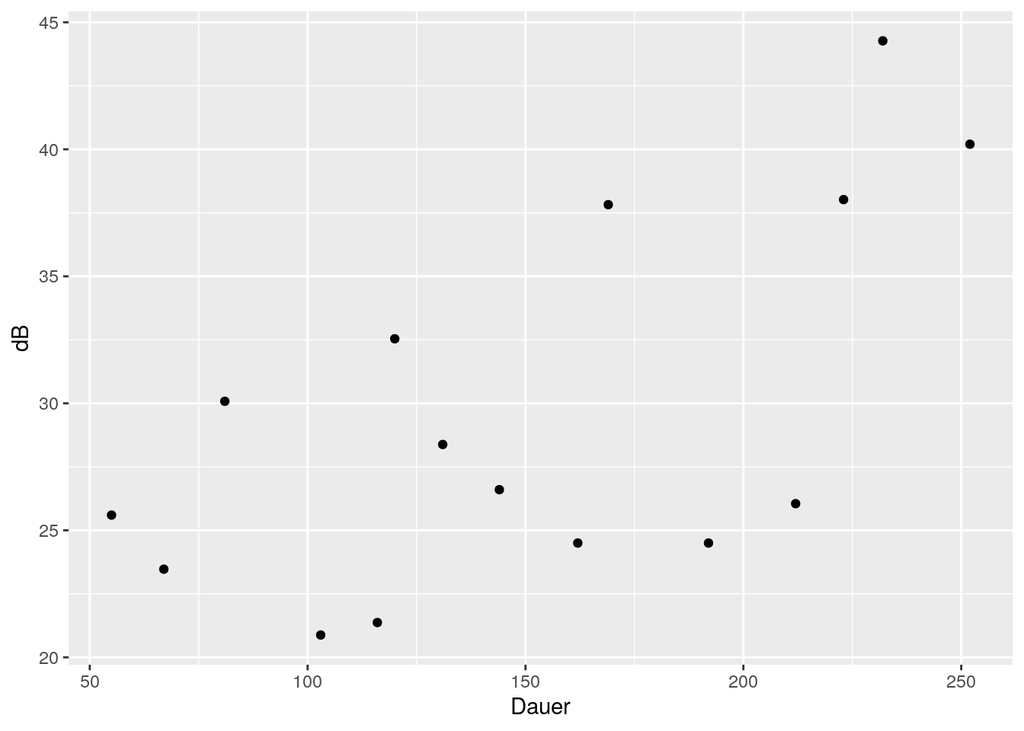

```r
# Punkte:
ggplot(int) +
  aes(x = Dauer, y = dB) +
  geom_point()
```

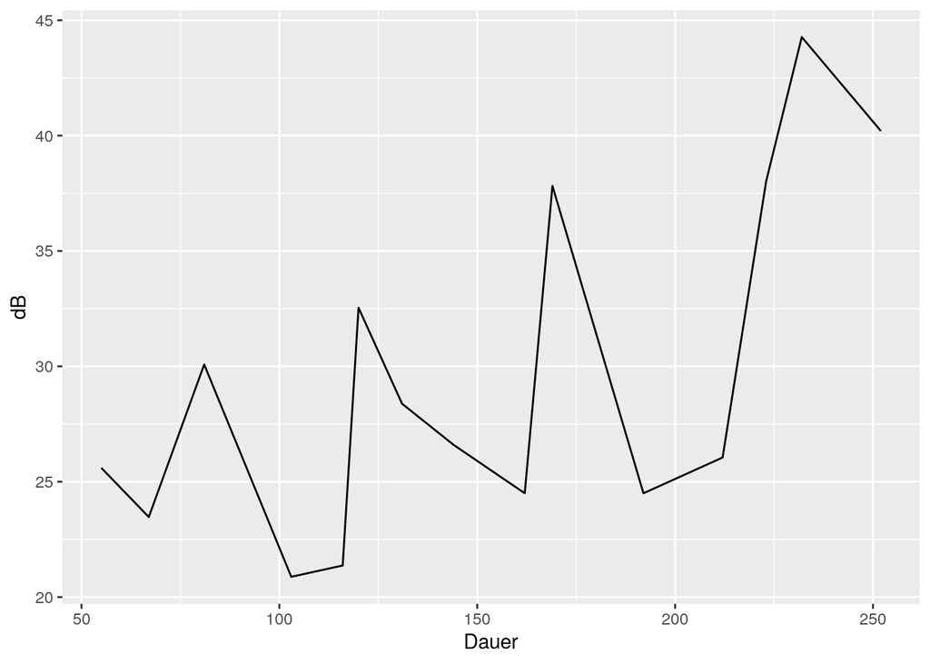

```r
# Linie:
ggplot(int) +
  aes(x = Dauer, y = dB) +
  geom_line()
```

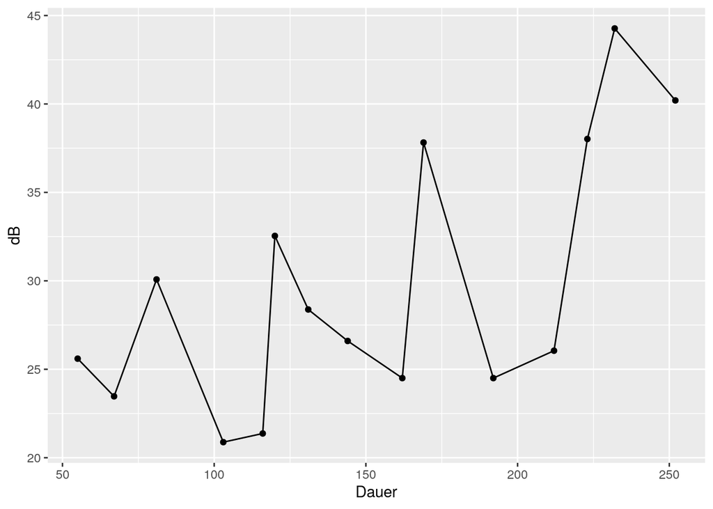

```r
# Beides:
ggplot(int) +
  aes(x = Dauer, y = dB) +
  geom_line() +
  geom_point()
```

Für (Regressions-)linien gibt es zwei Möglichkeiten: **`geom_abline()`** und **`geom_smooth()`**. `geom_abline()` funktioniert nur für gerade Linien und wird oft eher zur Annotation von Abbildungen genutzt (z.B. waagerechte oder vertikale Null-Linie einzeichnen). Wenn es tatsächlich nur um eine gerade horizontale Linie geht, wird häufig auch **`geom_hline()`** genutzt, oder das Gegestück für vertikale gerade Linien, **`geom_vline()`**. Wir fügen zum obigen Scatterplot gearde Linien hinzu:

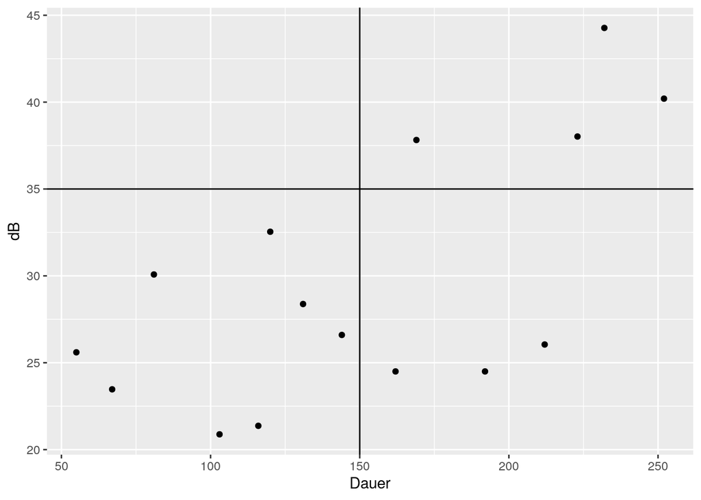

```r
ggplot(int) +
  aes(x = Dauer, y = dB) +
  geom_point() +
  geom_vline(xintercept = 150) +
  geom_hline(yintercept = 35)
```

Wenn wir vermuten, dass eine lineare Beziehung zwischen dB und Dauer vorliegen könnte, berechnen wir eine lineare Regression mit `lm()` und nutzen die Regressionskoeffizienten `coef()` für die Argumente `slope` und `intercept` bei `geom_abline()`:

```r
lreg <- lm(dB ~ Dauer, data = int)
coefs <- coef(lreg)
coefs
```

```
## (Intercept)       Dauer
## 18.28175138  0.07527832
```

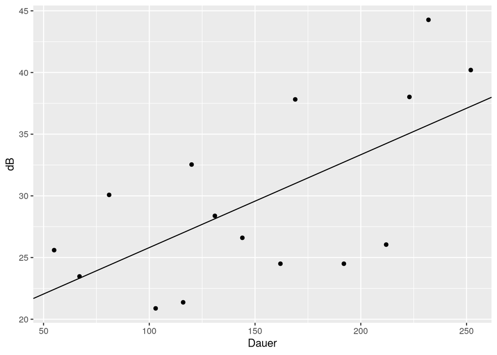

```r
ggplot(int) +
  aes(x = Dauer, y = dB) +
  geom_point() +
  geom_abline(intercept = coefs[1], slope = coefs[2])
```

`geom_smooth()` hingegen nutzt direkt Funktionen wie `lm()`, `glm()`, oder `gam()`, um Regressionslinien zu zeichen, die sowohl gerade als auch sigmoid als auch völlig frei sein können. Außerdem gibt die Funktion *by default* ein Konfidenzintervall von 95% (das Level kann mit `level` eingestellt werden; wenn gar kein Konfidenzintervall gewünscht ist: `se = F`). Wir nutzen nun `geom_smooth()` anstatt `geom_abline()`, wollen aber trotzdem eine gerade Regressionslinie:

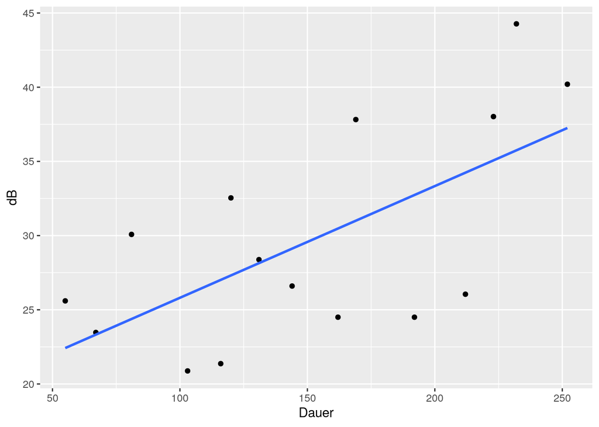

```r
ggplot(int) +
  aes(x = Dauer, y = dB) +
  geom_point() +
  geom_smooth(method = lm, se = F)
```

Wenn wir gar keine Methode bei `geom_smooth()` angeben, wird anhand der Datengröße die passende Methode ausgewählt. Die dabei entstehende Regressionslinie ist meist einfach eine freie Linie:

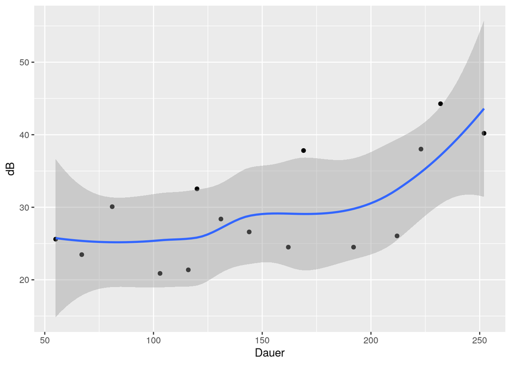

```r
ggplot(int) +
  aes(x = Dauer, y = dB) +
  geom_point() +
  geom_smooth()
```

Für logistische Regressionen mit `glm()` gibt es zwei Visualisierungsmöglichkeiten: Entweder als gerade Linie, wenn die *log odds* abgebildet werden, oder als Sigmoid, wenn die Proportionen abgebildet werden:

```r
df <- l.df %>%
  mutate(Erfolg = Urteil == "leiten",
         Misserfolg = !Erfolg) %>%
  group_by(stim) %>%
  dplyr::summarise(P = sum(Erfolg), Q = sum(Misserfolg)) %>%
  mutate(Proportion = P / (P+Q),
         log_odds = log(P/Q))
df
```

```
## # A tibble: 7 x 5
##    stim     P     Q Proportion log_odds
##   <int> <int> <int>      <dbl>    <dbl>
## 1     1     0    16      0     -Inf
## 2     2     0    16      0     -Inf
## 3     3     5    11      0.312   -0.788
## 4     4    14     2      0.875    1.95
## 5     5    14     2      0.875    1.95
## 6     6    15     1      0.938    2.71
## 7     7    16     0      1      Inf
```

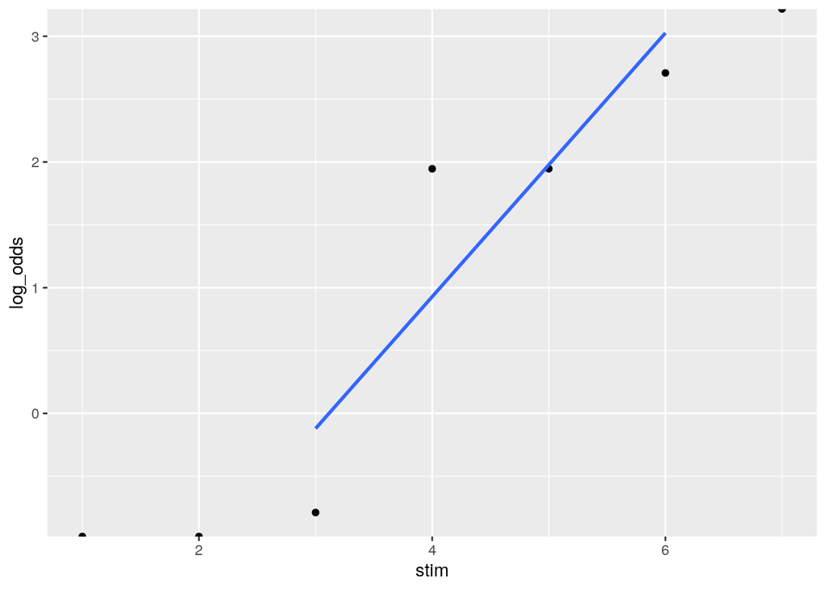

```r
# gerade Linie für log odds:
ggplot(df) +
  aes(x = stim, y = log_odds) +
  geom_point() +
  geom_smooth(method = glm, se = F)
```

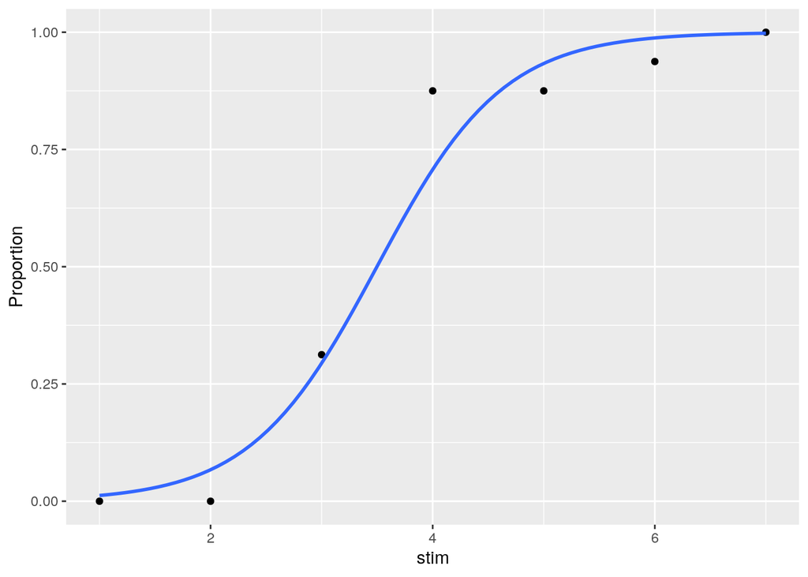

```r
# Sigmoid für Proportionen
ggplot(df) +
  aes(x = stim, y = Proportion) +
  geom_point() +
  geom_smooth(method = glm, se = F, method.args = list(family = binomial))
```

**Aufgabe**: Erstellen Sie einen Scatterplot für F2 in Abhängigkeit von der Dauer F1 im Data Frame `vdata`. Fügen Sie eine horizontale und eine vertikale Linie hinzu. Probieren Sie gerne auch `geom_abline()` und `geom_smooth()` aus.

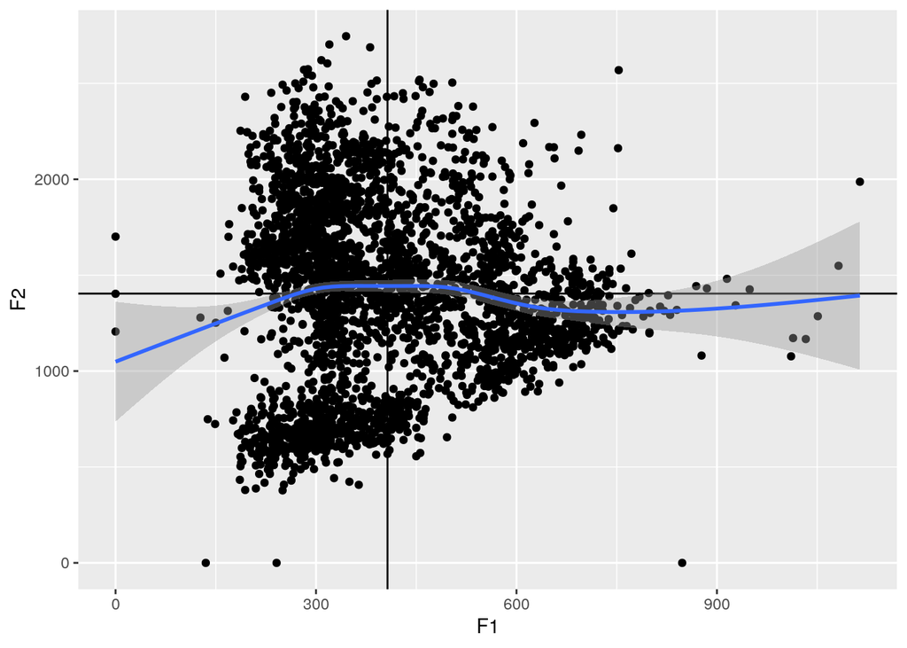

```r
ggplot(vdata) +
  aes(x = F1, y = F2) +
  geom_point() +
  geom_vline(xintercept = 407) +
  geom_hline(yintercept = 1404) +
  geom_smooth()
```

### 4.3.2 Boxplots

Boxplots sind die wohl wichtigsten wissenschaftlich genutzten Abbildungen. In R werden sie mit dem Befehl **`geom_boxplot()`** erstellt. Hier ist ein erstes Beispiel:

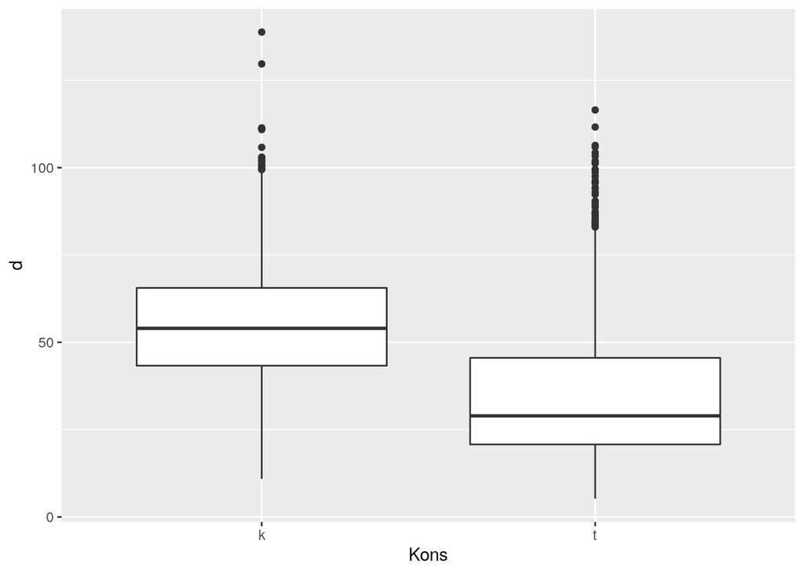

```r
ggplot(asp) +
  aes(x = Kons, y = d) +
  geom_boxplot()
```

Boxplots können auch horizontal erstellt werden (wobei das meist weniger übersichtlich ist):

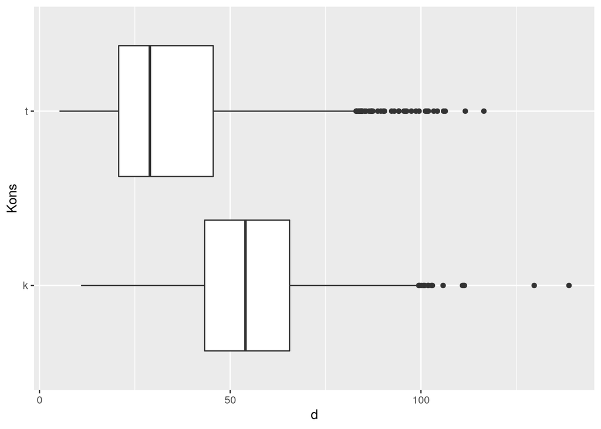

```r
ggplot(asp) +
  aes(x = d, y = Kons) +
  geom_boxplot()
```

Manchmal ist ein sogenannter Notch gewünscht; dafür nutzen wir das Argument `notch = T` (und ggf. `notchwidth`, um die Tiefe des Notches anzupassen):

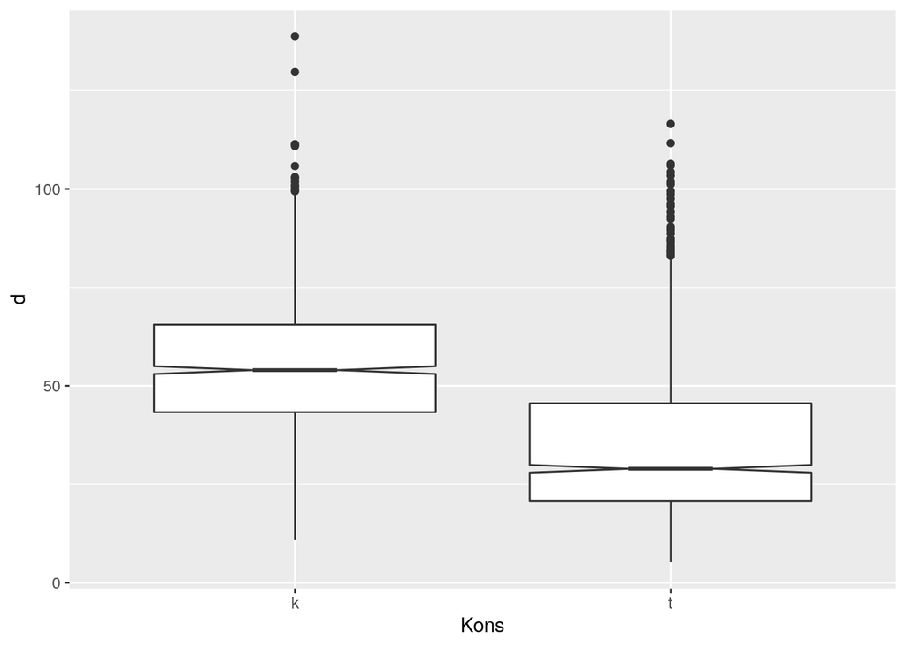

```r
ggplot(asp) +
  aes(x = Kons, y = d) +
  geom_boxplot(notch = T, notchwidth = 0.3)
```

Hier schließt sich auch der Kreis zum Anfang, wo wir `pivot_longer()` kennengelernt haben: Wenn wir einen Boxplot erzeugen wollen, der die Länge, Breite und Höhe von Diamanten in jeweils getrennten Boxen zeigt, geht das nur, indem wir zuerst den Data Frame `diamonds` umformen:

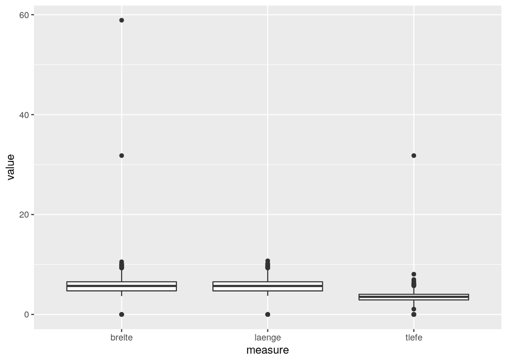

```r
diamonds %>% dplyr::rename(laenge = x, breite = y, tiefe = z) %>%
  pivot_longer(cols = c(laenge, breite, tiefe), names_to = "measure", values_to = "value") %>%
  ggplot() + aes(x = measure, y = value) + geom_boxplot()
```

Wir sehen in diesem (eigentlich schönen) Boxplot drei Outlier, die überhalb eines Wertes von 20 liegen. Die können wir z.B. mittels `filter()` noch eliminieren:

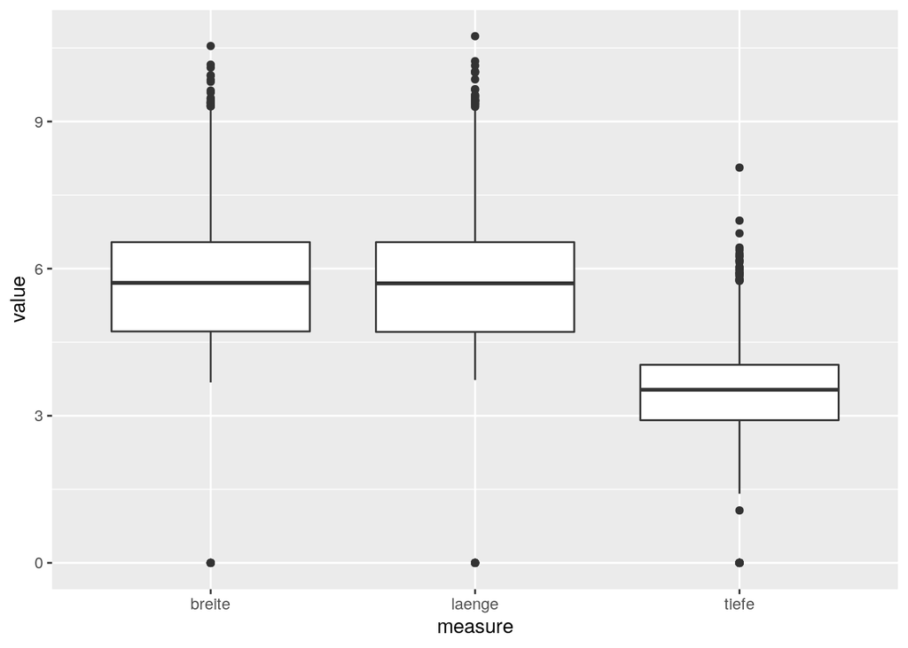

```r
diamonds %>% dplyr::rename(laenge = x, breite = y, tiefe = z) %>%
  pivot_longer(cols = c(laenge, breite, tiefe), names_to = "measure", values_to = "value") %>%
  filter(value < 20) %>%
  ggplot() + aes(x = measure, y = value) + geom_boxplot()
```

**Aufgabe**: Erstellen Sie einen Boxplot mit `vdata`, der die Dauer `dur` aufgeteilt nach Vokal `V` zeigt.

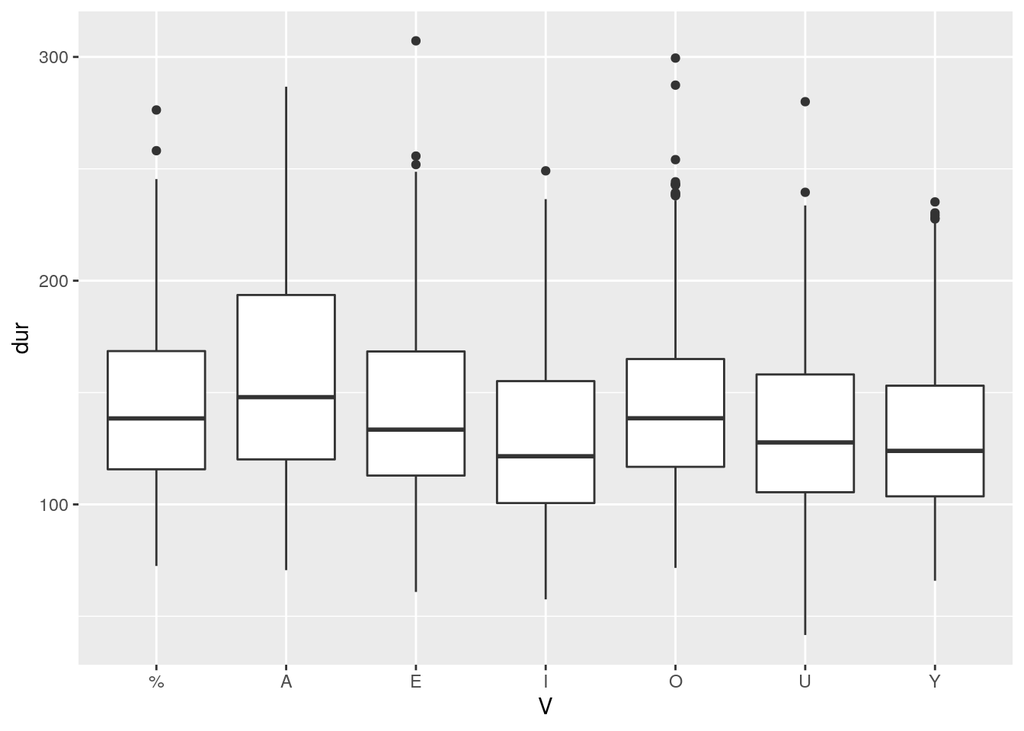

```r
ggplot(vdata) +
  aes(x = V, y = dur) +
  geom_boxplot()
```

### 4.3.3 Barplots

Eine weitere wichtige Abbildungsform sind Barplots. Der R-Befehl hierfür ist **`geom_bar()`**. Dabei darf nur entweder `x` oder `y` in den *aesthetic mappings* verwendet werden. Die zwei Variable, die abgebildet werden soll, wird mit `fill` angegeben, das die Stufen der Variable als Füllfarben darstellt. Mit dem Argument `position` kann zudem angegeben werden, wie die einzelnen Bars angeordnet werden sollen.

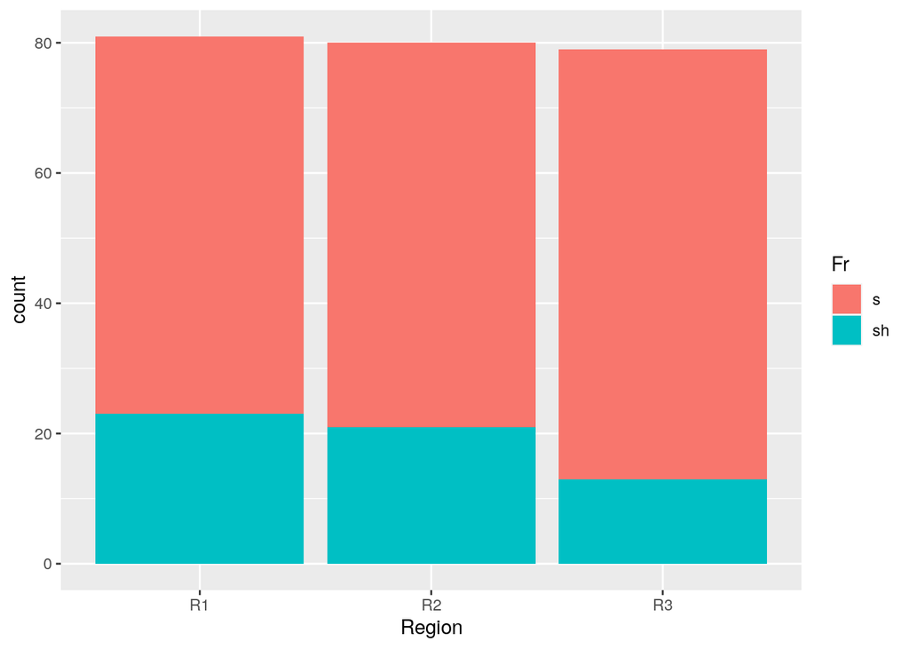

```r
# um den Count darzustellen:
ggplot(coronal) +
  aes(x = Region, fill = Fr) +
  geom_bar()
```

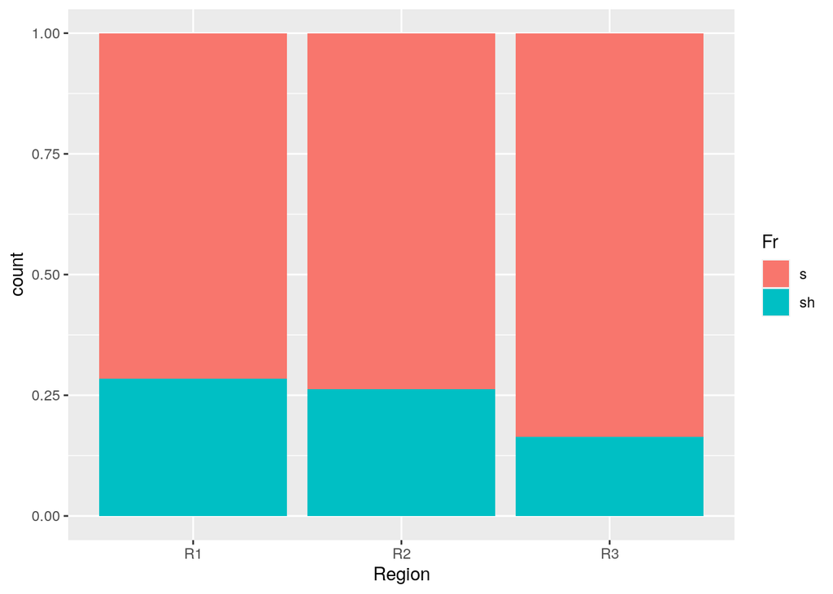

```r
# um die Proportionen darzustellen:
ggplot(coronal) +
  aes(x = Region, fill = Fr) +
  geom_bar(position = "fill")
```

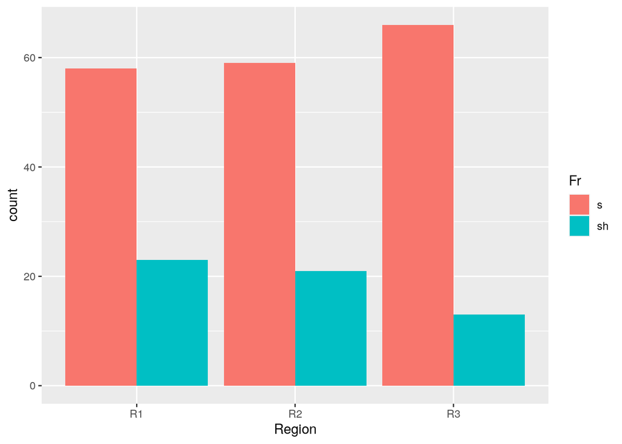

```r
# um die Balken nebeneinander zu stellen:
ggplot(coronal) +
  aes(x = Region, fill = Fr) +
  geom_bar(position = "dodge")
```

**Aufgabe**: Erstellen Sie einen Barplot mit dem Data Frame `titanic`, der zeigt, ob Passagiere der Titanic eher überlebt haben, wenn sie in der ersten statt der dritten Klasse reisten.

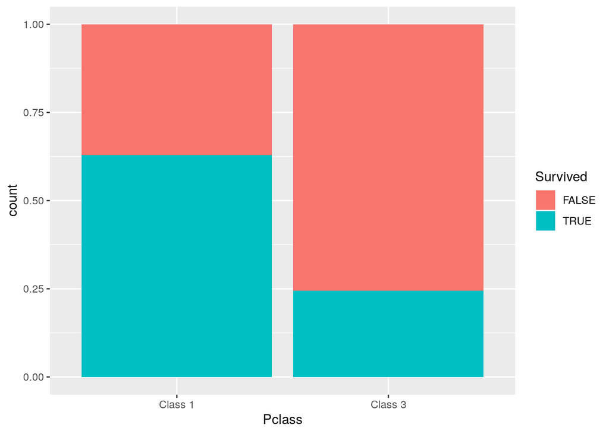

```r
ggplot(titanic) +
  aes(x = Pclass, fill = Survived) +
  geom_bar(position = "fill")
```

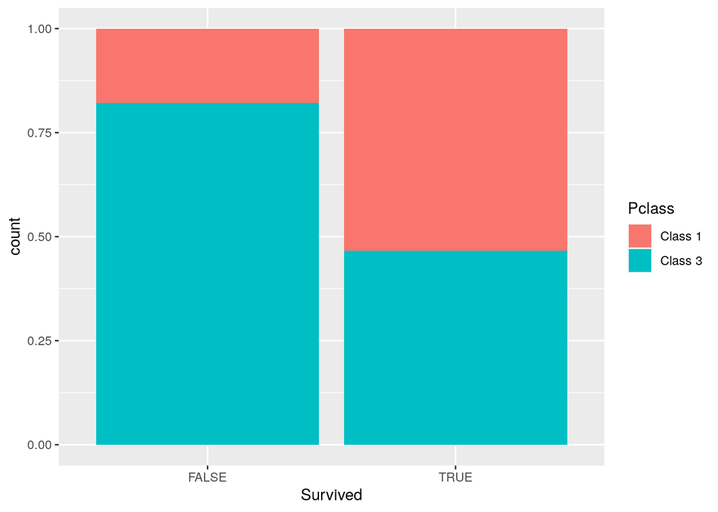

```r
# oder:
ggplot(titanic) +
  aes(x = Survived, fill = Pclass) +
  geom_bar(position = "fill")
```

### 4.3.4 Weitere Spezifikationen

Es gibt natürlich noch deutlich mehr Spezifikationen für die einzelnen Abbildungstypen als die Farbe, z.B. die Zeichengröße, den Linientyp, die Punktform, die Schriftart… Dazu gibt es eine Vignette:

```r
vignette("ggplot2-specs")
```

Die wichtigsten Spezifikationen sind:

- `col`: Umriss- bzw. Linienfarbe
- `fill`: Füllfarbe
- `shape`: Form
- `size`: Größe
- `lty`: Linientyp

#### 4.3.4.1 Achsenbeschriftungen

Die Beschriftungen der Achsen wird mit **`xlab()`** bzw. **`ylab()`** erstellt. Einen Titel können Sie mit **`ggtitle()`** hinzufügen. Ansonsten können Sie auch **`labs()`** nutzen für alle Labels zusammen:

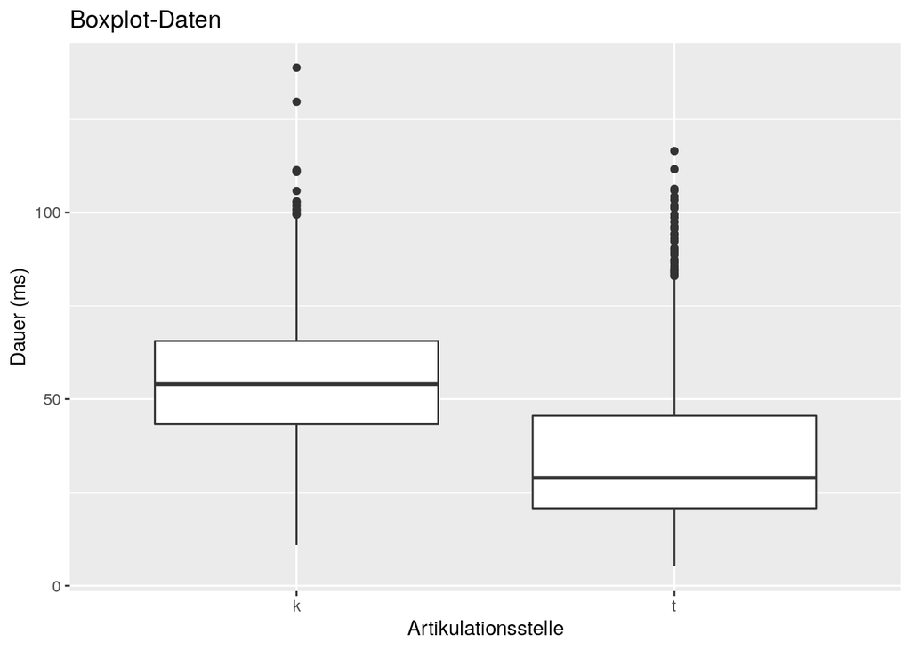

```r
ggplot(asp) +
  aes(x = Kons, y = d) +
  geom_boxplot() +
  xlab("Artikulationsstelle") +
  ylab("Dauer (ms)") +
  ggtitle("Boxplot-Daten")
```

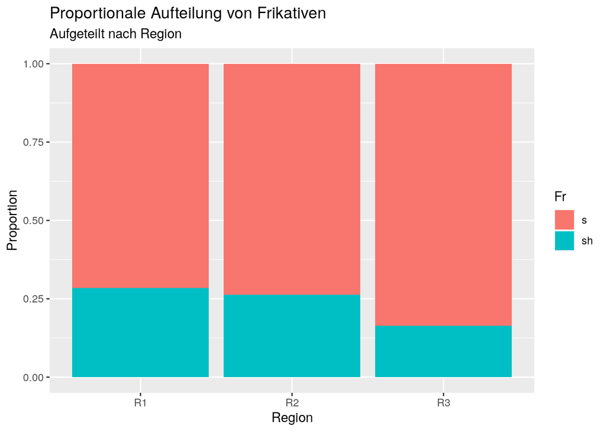

```r
ggplot(coronal) +
  aes(x = Region, fill = Fr) +
  geom_bar(position = "fill") +
  labs(x = "Region", y = "Proportion",
       title = "Proportionale Aufteilung von Frikativen",
       subtitle = "Aufgeteilt nach Region")
```

```r
# Platz zum Ausprobieren:
```

#### 4.3.4.2 Schriftzeichengröße

Die Default-Schriftzeichengröße der Achsenbeschriftung und Titel ist 11 oder kleiner. Vor allem wenn Sie Ihre Plots präsentieren, ist es sehr wichtig, dass Sie die Schriftzeichengröße verändern. Ich empfehle **mind. 18-24pt**. Hierfür müssen wir das **`theme()`** ändern.

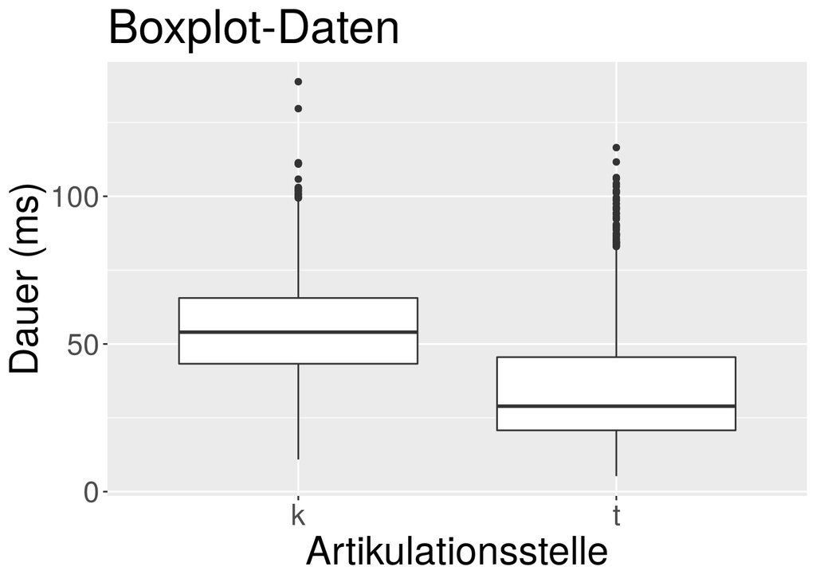

```r
ggplot(asp) +
  aes(x = Kons, y = d) +
  geom_boxplot() +
  xlab("Artikulationsstelle") +
  ylab("Dauer (ms)") +
  ggtitle("Boxplot-Daten") +
  theme(text = element_text(size = 24),            # Beschriftungen & Titel
        axis.text = element_text(size = 18))       # Achsenbeschriftungen
```

Das `theme()` ist z.B. für die Hintergrundfarbe der Plots, die Achsen, und vieles weitere zuständig. Diese [Übersicht an Argumenten](https://ggplot2.tidyverse.org/reference/theme.html) der Funktion `theme()` zeigt Ihnen, wie viel Sie damit einstellen können. Außerdem gibt es verschiedene [grundlegende `themes`](https://ggplot2.tidyverse.org/reference/ggtheme.html).

```r
# Platz zum Ausprobieren:
```

#### 4.3.4.3 Farben

`ggplot2` verwendet standardmäßig immer dieselbe Farbpalette. Ihnen stehen aber deutlich mehr Farben zur Verfügung, wie Ihnen diese [Farbauswahl](http://www.stat.columbia.edu/~tzheng/files/Rcolor.pdf) zeigt. Die Farbnamen bekommen Sie auch mit:

```r
colors()
```

```r
# die ersten 10 anzeigen:
colors()[1:10]
```

```
##  [1] "white"         "aliceblue"     "antiquewhite"  "antiquewhite1"
##  [5] "antiquewhite2" "antiquewhite3" "antiquewhite4" "aquamarine"
##  [9] "aquamarine1"   "aquamarine2"
```

Ihre Farbauswahl teilen Sie mit den Argumenten `col` (Umriss- bzw. Linienfarbe) bzw. `fill` (Füllfarbe) im *aesthetic mapping* mit:

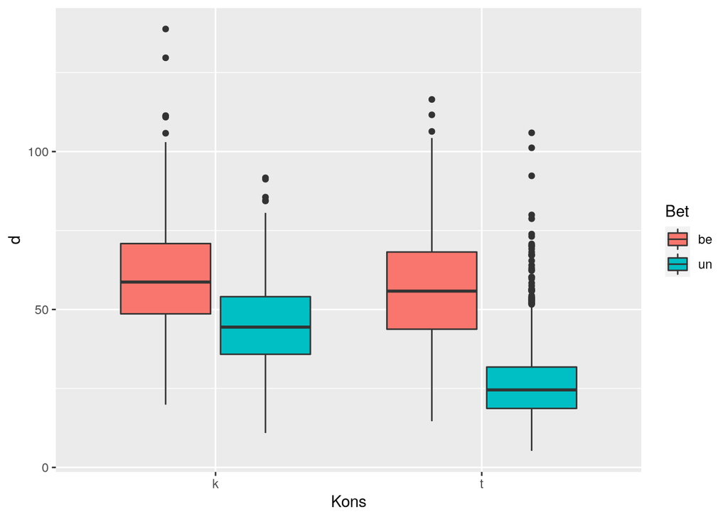

```r
# mit "fill" (empfohlen für Boxplots)
ggplot(asp) +
  aes(x = Kons, y = d, fill = Bet) +
  geom_boxplot()
```

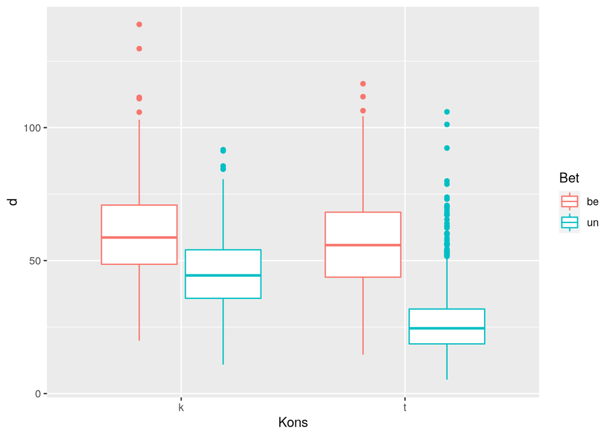

```r
# mit "col"
ggplot(asp) +
  aes(x = Kons, y = d, col = Bet) +
  geom_boxplot()
```

Wie Sie sehen, wurde diesen zwei Plots automatisch eine Legende hinzugefügt, die aufschlüsselt, welche Farben für welche Werte der Variable `Bet` verwendet wurden. Jetzt wollen wir unsere Farben selbst auswählen:

[figure not shown]

```r
# "fill" mit eigenen Farben
farben <- c("darkgoldenrod1", "navy")
ggplot(asp) +
  aes(y = d, x = Kons, fill = Bet) +
  geom_boxplot(fill = farben)
```

Hier gibt es keine Legende. Wenn wir bei selbst gewählten Farben eine Legende haben wollen, benutzen wir eine Funktion namens **`scale_color_manual()`** bzw. **`scale_fill_manual()`**:

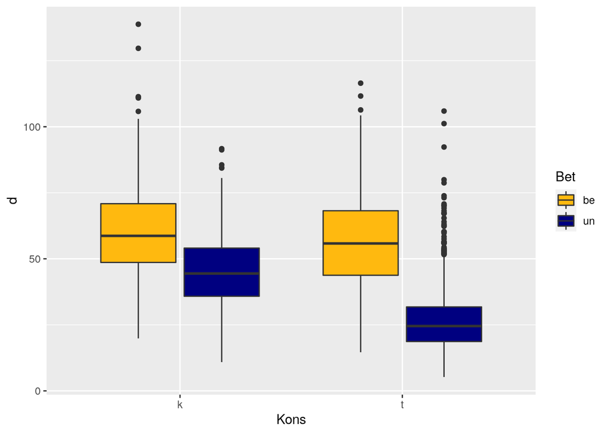

```r
# "fill" mit eigenen Farben
farben <- c("darkgoldenrod1", "navy")
ggplot(asp) +
  aes(y = d, x = Kons, fill = Bet) +
  geom_boxplot() +
  scale_fill_manual(values = farben)
```

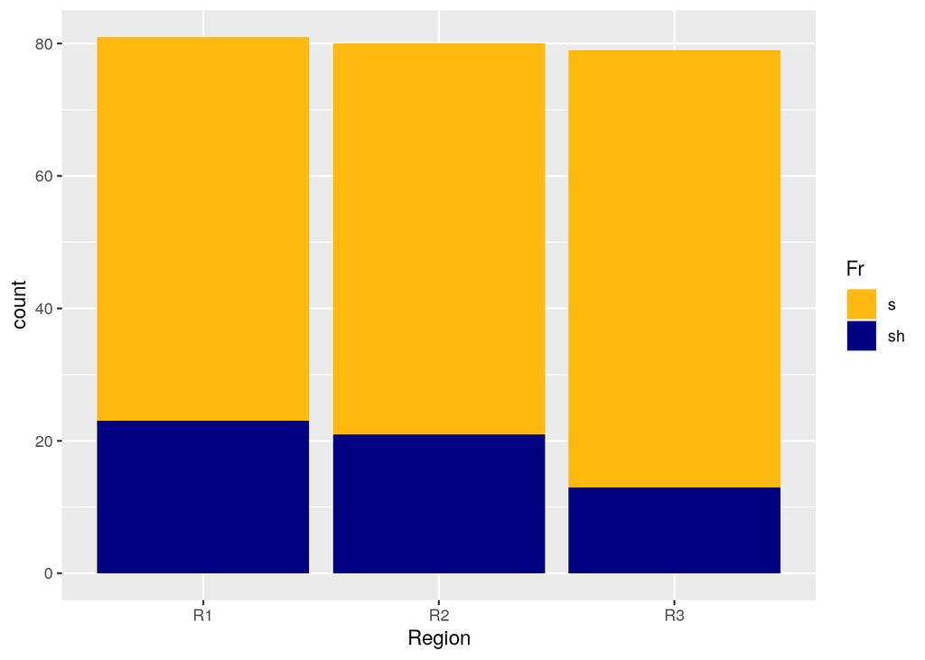

```r
# dasselbe für den Barplot
ggplot(coronal) +
  aes(x = Region, fill = Fr) +
  geom_bar() +
  scale_fill_manual(values = farben)
```

Für Boxplots gibt es übrigens die Möglichkeit, die Outlier unabhängig von der Box zu gestalten:

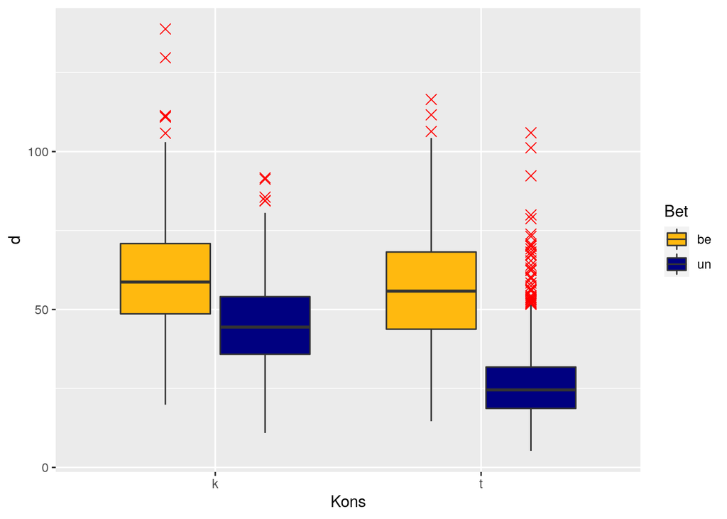

```r
farben <- c("darkgoldenrod1", "navy")
ggplot(asp) +
  aes(y = d, x = Kons, fill = Bet) +
  geom_boxplot(outlier.color = "red", outlier.shape = 4, outlier.size = 3) +
  scale_fill_manual(values = farben)
```

```r
# Platz zum Ausprobieren:
```

#### 4.3.4.4 Linetypes und Punkte

Mit den Argumenten `shape` und `lty` können die Punkte und Linien verändert werden. Wir nutzen hier zusätzlich das Argument `size`, um die Punkte zu vergrößern und die Linie etwas breiter zu machen.

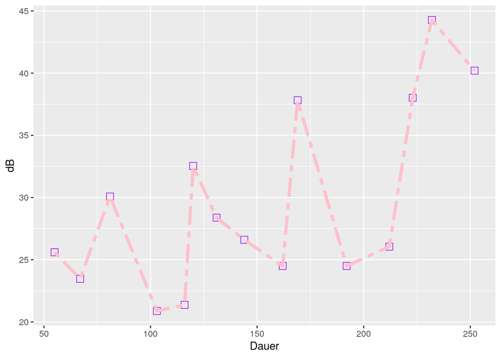

```r
ggplot(int) +
  aes(x = Dauer, y = dB) +
  geom_point(col = "purple", shape = 0, size = 3) +
  geom_line(col = "pink", size = 1.5, lty = "twodash")
```

```r
# Platz zum Ausprobieren:
```